# Project: Investigate a Dataset - TMDB

### Research Question 2 (Which genres are most popular from year to year?)

```python
df['genres_1'] = df['genres'].str.split('|').str.get(0)
df['genres_2'] = df['genres'].str.split('|').str.get(1)
df['genres_3'] = df['genres'].str.split('|').str.get(2)
df['genres_4'] = df['genres'].str.split('|').str.get(3)
df['genres_5'] = df['genres'].str.split('|').str.get(4)

df['genres_5'].value_counts()

# Split 'genres' into individual columns
```

```
Thriller           119
Science Fiction     66
Family              59
Romance             45
Fantasy             40
Mystery             37
Crime               23
War                 22
Drama               19
Comedy              15
Music               14
Adventure           14
TV Movie            14
Horror              11
Action              10
Western             10
Foreign              9
History              4
Animation            3
Name: genres_5, dtype: int64
```

```python
genres_1 = df['genres_1'].value_counts()
genres_2 = df['genres_2'].value_counts()
genres_3 = df['genres_3'].value_counts()
genres_4 = df['genres_4'].value_counts()
genres_5 = df['genres_5'].value_counts()
genres = genres_1 + genres_2 + genres_3 + genres_4 + genres_5
genres

# Check the frequency of each genres
# Choose the top 10 of frequency to do further analysis
```

```
Action             2353.0
Adventure          1454.0
Animation           687.0
Comedy             3770.0
Crime              1345.0
Documentary           NaN
Drama              4715.0
Family             1217.0
Fantasy             904.0
Foreign             179.0
History             323.0
Horror             1623.0
Music               398.0
Mystery             803.0
Romance            1696.0
Science Fiction    1206.0
TV Movie            162.0
Thriller           2881.0
War                 264.0
Western             164.0
dtype: float64
```

```python
df['Drama'] = (df['genres_1'] == 'Drama') | (df['genres_2'] == 'Drama') | (df['genres_3'] == 'Drama') | (df['genres_4'] == 'Drama') | (df['genres_5'] == 'Drama')
df['Comedy'] = (df['genres_1'] == 'Comedy') | (df['genres_2'] == 'Comedy') | (df['genres_3'] == 'Comedy') | (df['genres_4'] == 'Comedy') | (df['genres_5'] == 'Comedy')
df['Thriller'] = (df['genres_1'] == 'Thriller') | (df['genres_2'] == 'Thriller') | (df['genres_3'] == 'Thriller') | (df['genres_4'] == 'Thriller') | (df['genres_5'] == 'Thriller')
df['Action'] = (df['genres_1'] == 'Action') | (df['genres_2'] == 'Action') | (df['genres_3'] == 'Action') | (df['genres_4'] == 'Action') | (df['genres_5'] == 'Action')
df['Romance'] = (df['genres_1'] == 'Romance') | (df['genres_2'] == 'Romance') | (df['genres_3'] == 'Romance') | (df['genres_4'] == 'Romance') | (df['genres_5'] == 'Romance')
df['Horror'] = (df['genres_1'] == 'Horror') | (df['genres_2'] == 'Horror') | (df['genres_3'] == 'Horror') | (df['genres_4'] == 'Horror') | (df['genres_5'] == 'Horror')
df['Adventure'] = (df['genres_1'] == 'Adventure') | (df['genres_2'] == 'Adventure') | (df['genres_3'] == 'Adventure') | (df['genres_4'] == 'Adventure') | (df['genres_5'] == 'Adventure')
df['Crime'] = (df['genres_1'] == 'Crime') | (df['genres_2'] == 'Crime') | (df['genres_3'] == 'Crime') | (df['genres_4'] == 'Crime') | (df['genres_5'] == 'Crime')
df['Family'] = (df['genres_1'] == 'Family') | (df['genres_2'] == 'Family') | (df['genres_3'] == 'Family') | (df['genres_4'] == 'Family') | (df['genres_5'] == 'Family')
df['Science Fiction'] = (df['genres_1'] == 'Science Fiction') | (df['genres_2'] == 'Science Fiction') | (df['genres_3'] == 'Science Fiction') | (df['genres_4'] == 'Science Fiction') | (df['genres_5'] == 'Science Fiction')

# Give a mark for each genres
```

```python
# Calculate the mean of popularity by genres and release_year
# Merge all the tables in the end

df_drama = df[df['Drama'] == True]
Drama_Year_mean = df_drama.groupby(['release_year'], as_index = False)['popularity'].mean()
```

```python
df_comedy = df[df['Comedy'] == True]
Comedy_Year_mean = df_comedy.groupby(['release_year'], as_index = False)['popularity'].mean()
```

```python
df_combined = Drama_Year_mean.merge(Comedy_Year_mean, left_on='release_year', right_on='release_year', how='inner')
df_combined.head(1)
```

|  | release_year | popularity_x | popularity_y |
| --- | --- | --- | --- |
| 0 | 1960 | 0.566305 | 0.396 |

```python
df_Thriller = df[df['Thriller'] == True]
Thriller_Year_mean = df_Thriller.groupby(['release_year'], as_index = False)['popularity'].mean()
```

```python
df_combined = df_combined.merge(Thriller_Year_mean, left_on='release_year', right_on='release_year', how='inner', suffixes=('_drama', '_comedy', '_thriller'))
df_combined.head(1)
```

|  | release_year | popularity_x | popularity_y | popularity |
| --- | --- | --- | --- | --- |
| 0 | 1960 | 0.566305 | 0.396 | 0.81191 |

```python
df_Action = df[df['Action'] == True]
Action_Year_mean = df_Action.groupby(['release_year'], as_index = False)['popularity'].mean()
```

```python
df_combined = df_combined.merge(Action_Year_mean, left_on='release_year', right_on='release_year', how='inner')
df_combined.head(1)
```

|  | release_year | popularity_x | popularity_y | popularity_x | popularity_y |
| --- | --- | --- | --- | --- | --- |
| 0 | 1960 | 0.566305 | 0.396 | 0.81191 | 0.590724 |

```python
df_Romance = df[df['Romance'] == True]
Romance_Year_mean = df_Romance.groupby(['release_year'], as_index = False)['popularity'].mean()
```

```python
df_combined = df_combined.merge(Romance_Year_mean, left_on='release_year', right_on='release_year', how='inner')
df_combined.head(1)
```

|  | release_year | popularity_x | popularity_y | popularity_x | popularity_y | popularity |
| --- | --- | --- | --- | --- | --- | --- |
| 0 | 1960 | 0.566305 | 0.396 | 0.81191 | 0.590724 | 0.541227 |

```python
df_Horror = df[df['Horror'] == True]
Horror_Year_mean = df_Horror.groupby(['release_year'], as_index = False)['popularity'].mean()
```

```python
df_combined = df_combined.merge(Horror_Year_mean, left_on='release_year', right_on='release_year', how='inner')
df_combined.head(1)
```

|  | release_year | popularity_x | popularity_y | popularity_x | popularity_y | popularity_x | popularity_y |
| --- | --- | --- | --- | --- | --- | --- | --- |
| 0 | 1960 | 0.566305 | 0.396 | 0.81191 | 0.590724 | 0.541227 | 0.59145 |

```python
df_Adventure = df[df['Adventure'] == True]
Adventure_Year_mean = df_Adventure.groupby(['release_year'], as_index = False)['popularity'].mean()
```

```python
df_combined = df_combined.merge(Adventure_Year_mean, left_on='release_year', right_on='release_year', how='inner')
df_combined.head(1)
```

|  | release_year | popularity_x | popularity_y | popularity_x | popularity_y | popularity_x | popularity_y | popularity |
| --- | --- | --- | --- | --- | --- | --- | --- | --- |
| 0 | 1960 | 0.566305 | 0.396 | 0.81191 | 0.590724 | 0.541227 | 0.59145 | 0.700981 |

```python
df_Crime = df[df['Crime'] == True]
Crime_Year_mean = df_Crime.groupby(['release_year'], as_index = False)['popularity'].mean()
```

```python
df_combined = df_combined.merge(Crime_Year_mean, left_on='release_year', right_on='release_year', how='inner')
df_combined.head(1)
```

|  | release_year | popularity_x | popularity_y | popularity_x | popularity_y | popularity_x | popularity_y | popularity_x | popularity_y |
| --- | --- | --- | --- | --- | --- | --- | --- | --- | --- |
| 0 | 1960 | 0.566305 | 0.396 | 0.81191 | 0.590724 | 0.541227 | 0.59145 | 0.700981 | 0.346479 |

```python
df_Family = df[df['Family'] == True]
Family_Year_mean = df_Family.groupby(['release_year'], as_index = False)['popularity'].mean()
```

```python
df_combined = df_combined.merge(Family_Year_mean, left_on='release_year', right_on='release_year', how='inner')
df_combined.head(1)
```

|  | release_year | popularity_x | popularity_y | popularity_x | popularity_y | popularity_x | popularity_y | popularity_x | popularity_y | popularity |
| --- | --- | --- | --- | --- | --- | --- | --- | --- | --- | --- |
| 0 | 1960 | 0.566305 | 0.396 | 0.81191 | 0.590724 | 0.541227 | 0.59145 | 0.700981 | 0.346479 | 0.278064 |

```python
df_Science_Fiction = df[df['Science Fiction'] == True]
Science_Fiction_Year_mean = df_Science_Fiction.groupby(['release_year'], as_index = False)['popularity'].mean()
```

```python
df_combined = df_combined.merge(Science_Fiction_Year_mean, left_on='release_year', right_on='release_year', how='inner')
df_combined.head(1)
```

|  | release_year | popularity_x | popularity_y | popularity_x | popularity_y | popularity_x | popularity_y | popularity_x | popularity_y | popularity_x | popularity_y |
| --- | --- | --- | --- | --- | --- | --- | --- | --- | --- | --- | --- |
| 0 | 1960 | 0.566305 | 0.396 | 0.81191 | 0.590724 | 0.541227 | 0.59145 | 0.700981 | 0.346479 | 0.278064 | 0.327905 |

```python
df_combined.columns = ['release_year', 'popularity_Drama', 'popularity_Comedy', 'popularity_Thriller', 'popularity_Action', 'popularity_Romance', 'popularity_Horror', 'popularity_Adventure', 'popularity_Crime', 'popularity_Family', 'popularity_Science_Fiction']
```

```python
df_combined.head(1)
```

|  | release_year | popularity_Drama | popularity_Comedy | popularity_Thriller | popularity_Action | popularity_Romance | popularity_Horror | popularity_Adventure | popularity_Crime | popularity_Family | popularity_Science_Fiction |
| --- | --- | --- | --- | --- | --- | --- | --- | --- | --- | --- | --- |
| 0 | 1960 | 0.566305 | 0.396 | 0.81191 | 0.590724 | 0.541227 | 0.59145 | 0.700981 | 0.346479 | 0.278064 | 0.327905 |

```
array([[<AxesSubplot: title={'center': 'popularity_Drama'}>]],
      dtype=object)
```

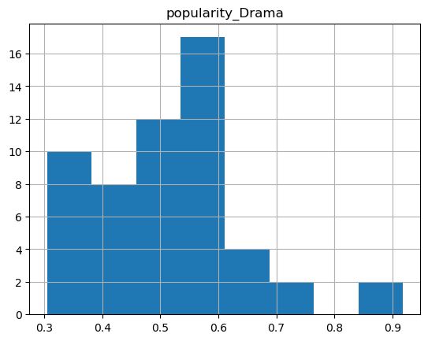

```python
df_combined.hist(column='popularity_Drama', bins = 'auto')
```

```
array([[<AxesSubplot: title={'center': 'popularity_Comedy'}>]],
      dtype=object)
```

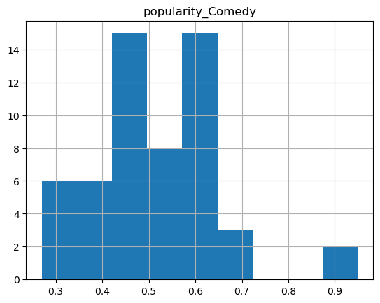

```python
df_combined.hist(column='popularity_Comedy', bins = 'auto')
```

```
array([[<AxesSubplot: title={'center': 'popularity_Thriller'}>]],
      dtype=object)
```

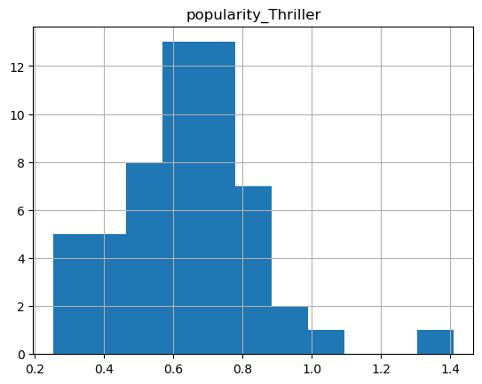

```python
df_combined.hist(column='popularity_Thriller', bins = 'auto')
```

```
array([[<AxesSubplot: title={'center': 'popularity_Action'}>]],
      dtype=object)
```

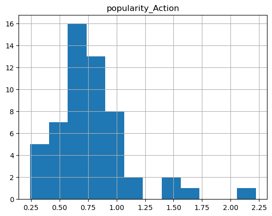

```python
df_combined.hist(column='popularity_Action', bins = 'auto')
```

```
array([[<AxesSubplot: title={'center': 'popularity_Romance'}>]],
      dtype=object)
```

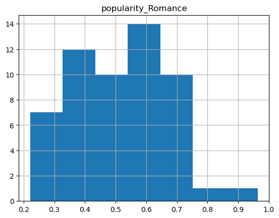

```python
df_combined.hist(column='popularity_Romance', bins = 'auto')
```

```
array([[<AxesSubplot: title={'center': 'popularity_Horror'}>]],
      dtype=object)
```

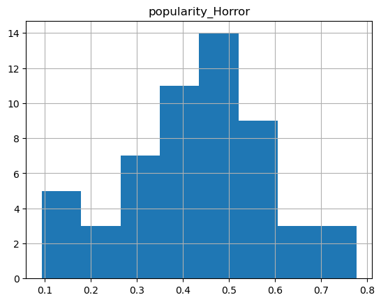

```python
df_combined.hist(column='popularity_Horror', bins = 'auto')
```

```
array([[<AxesSubplot: title={'center': 'popularity_Adventure'}>]],
      dtype=object)
```

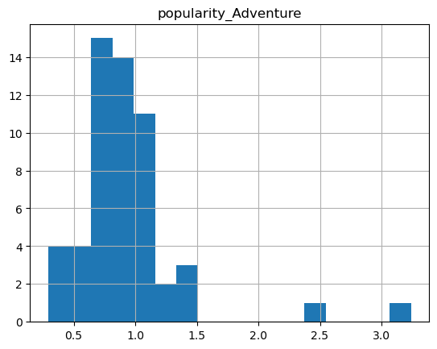

```python
df_combined.hist(column='popularity_Adventure', bins = 'auto')
```

```
array([[<AxesSubplot: title={'center': 'popularity_Crime'}>]],
      dtype=object)
```

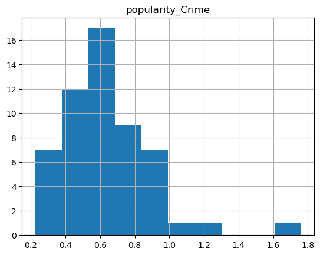

```python
df_combined.hist(column='popularity_Crime', bins = 'auto')
```

```
array([[<AxesSubplot: title={'center': 'popularity_Family'}>]],
      dtype=object)
```

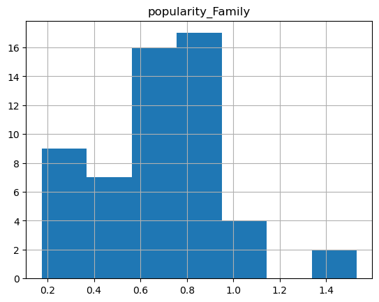

```python
df_combined.hist(column='popularity_Family', bins = 'auto')
```

```
array([[<AxesSubplot: title={'center': 'popularity_Science_Fiction'}>]],
      dtype=object)
```

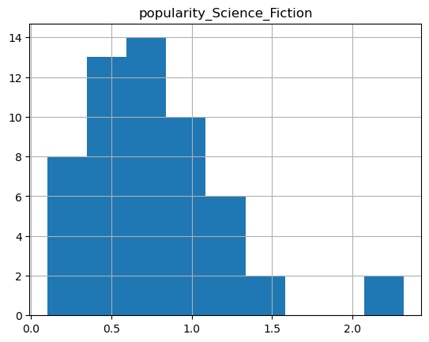

```python
df_combined.hist(column='popularity_Science_Fiction', bins = 'auto')
```

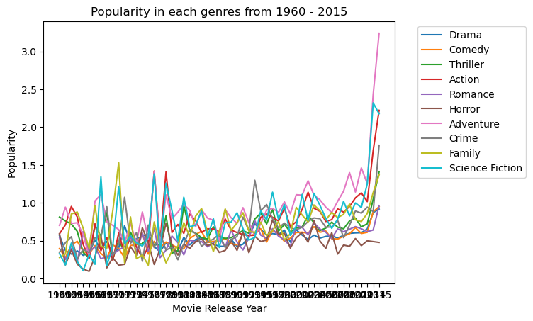

```python
plt.plot(df_combined['release_year'], df_combined['popularity_Drama'], label = 'Drama')
plt.plot(df_combined['release_year'], df_combined['popularity_Comedy'], label = 'Comedy')
plt.plot(df_combined['release_year'], df_combined['popularity_Thriller'], label = 'Thriller')
plt.plot(df_combined['release_year'], df_combined['popularity_Action'], label = 'Action')
plt.plot(df_combined['release_year'], df_combined['popularity_Romance'], label = 'Romance')
plt.plot(df_combined['release_year'], df_combined['popularity_Horror'], label = 'Horror')
plt.plot(df_combined['release_year'], df_combined['popularity_Adventure'], label = 'Adventure')
plt.plot(df_combined['release_year'], df_combined['popularity_Crime'], label = 'Crime')
plt.plot(df_combined['release_year'], df_combined['popularity_Family'], label = 'Family')
plt.plot(df_combined['release_year'], df_combined['popularity_Science_Fiction'], label = 'Science Fiction')

plt.title('Popularity in each genres from 1960 - 2015')
plt.xlabel("Movie Release Year")
plt.ylabel("Popularity")
plt.legend(bbox_to_anchor=(1.05, 1))

# We could see the most popular genres changes year by year
# Horror never be the most popular genres
# Adventure and Science Fiction are popular in many years
```

# Question 1 (What kinds of properties are associated with movies that have high revenues?)

> Higer vote_average would have more chance to get higher revenue, but we can see the movie with highist revenue is not with highist vote_average.

> We can get that audience like movie with vote_average 5-8, but there is no market for the movies with vote_average higher or lower than 5-8.

> Runtime is not the main factor to make higher revenue

# Question 2 (Which genres are most popular from year to year?)

> The most popular genres changes year by year

> Horror never be the most popular genres

> Adventure and Science Fiction are the most popular in many years

## Limitations

> I have used TMBD Movies dataset for this analysis. This analysis is limited to the provided dataset, which is data from 1960 - 2015 and I do not confirm each column and value of this dataset.

> For the revenue column, we do not check the currency it used and assume they are used in the same currency to analyze.

> Dropping missing or Null values from variables of our interest might skew our analysis and could show unintentional bias towards the relationship being analyzed. etc.